# Data Skills 04 - Design Features with ggplot2

Christopher Prener, Ph.D.

(November 30, 2022)

## Dependencies

This notebook requires two packages from the `tidyverse` as well as two additional packages:

```r
# tidyverse packages
library(dplyr)     # data wrangling
library(ggplot2)   # read and write csv files

# manage file paths
library(here)      # manage file paths
```

## Load Data

For today’s session, we’ll use the `penguins` data in the `palmerpenguins` package.

```r
penguins <- palmerpenguins::penguins
```

## Reviewing Our Last Plot

This is our code from last week. We’ll start by reviewing some of the basic elements of `ggplot2`!

```r
p <- ggplot(data = penguins, mapping = aes(x = bill_length_mm, y = bill_depth_mm,
                                      color = species)) +
  geom_point() +
  geom_smooth(method = "lm", formula = y ~ x) +
  scale_x_continuous(limits = c(30, 60), breaks = seq(30, 60, by = 5)) +
  scale_y_continuous(limits = c(12, 22), breaks = seq(12, 22, by = 2)) +
  scale_color_brewer(palette = "Dark2", name = "Species") +
  labs(
    title = "Penguin Bill Size",
    subtitle = "Multiple Islands",
    x = "Bill Length (mm)",
    y = "Bill Depth (mm)",
    caption = "Plot by Chris Prener"
  )
```

Now that we’ve finalized our plot, we can save it using `ggsave()`:

```r
ggsave(filename = here("results", "bill_length_depth.png"), plot = p)
```

## Adding More Design Elements

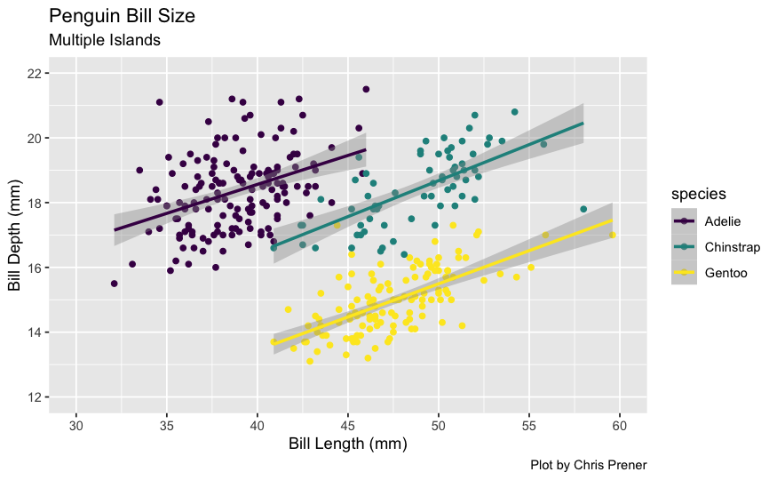

```r
p <- ggplot(data = penguins, mapping = aes(x = bill_length_mm, y = bill_depth_mm,
                                      color = species)) +
  geom_point() +
  geom_smooth(method = "lm", formula = y ~ x) +
  scale_x_continuous(limits = c(30, 60), breaks = seq(30, 60, by = 5)) +
  scale_y_continuous(limits = c(12, 22), breaks = seq(12, 22, by = 2)) +
  scale_color_viridis_d() +
  labs(
    title = "Penguin Bill Size",
    subtitle = "Multiple Islands",
    x = "Bill Length (mm)",
    y = "Bill Depth (mm)",
    caption = "Plot by Chris Prener"
  )

p
```

Now that we’ve finalized our plot, we can save it using `ggsave()`:

```r
ggsave(filename = here("results", "bill_length_depth_new.png"), plot = p)
```

## Experimentation

Now, you try adjusting the plot above to fit new data, comparing `flipper_length_mm` and `body_mass_g`. Save your plot when you’re done!

```r
p <- ggplot(data = penguins, mapping = aes(x = flipper_length_mm, y = body_mass_g,
                                      color = species)) +
  geom_point() +
  scale_color_brewer(palette = "Set1", name = "Species") +
  scale_x_continuous(
    limits = c(170, 240),
    breaks = seq(170, 240, by = 10)
  ) +
  scale_y_continuous(
    limits = c(2500, 6500),
    breaks = seq(2500, 6500, by = 500)
  ) +
  labs(
    title = "Body Mass and Flipper Length by Species",
    x = "Flipper Length (mm)",
    y = "Body Mass (g)"
  )

p
```

[output not shown]

Now that we’ve finalized our plot, we can save it using `ggsave()`:

```r
ggsave(filename = here("results", "flipper_mass.png"), plot = p)
```